# The People v. Hasty AI

Protecting the Right to be Annoyed

Taylor Washington, Illinois Institute of Technology (Project Lead)[^1]

Laasya Priya Vemuri, Illinois Institute of Technology (Associate Fellow)[^2]

Spring 2026 SoReMo Fellowship Project Final Technical Report

[Back to journal](https://soremo.library.iit.edu)

# Contributors and Project Details

## The SoReMo Initiative at Illinois Institute of Technology

This student project was developed under the auspices of the Socially Responsible Modeling, Computation, and Design (SoReMo) Initiative at Illinois Tech in the Spring 2026 semester. SoReMo is a multidisciplinary forum that empowers student fellows to apply technical knowledge—in modeling, data science, design, etc.—toward solving pressing societal challenges. By connecting student research with a network of faculty advisors and community stakeholders, SoReMo ensures that technical innovation is guided by ethics, equity, and transparency.

“The People v. Hasty AI” embodies the SoReMo mission by taking the “invisible” data of the Illinois AI boom and translating it into actionable insights for the communities most impacted by this industrial expansion.

*Research Areas/Relevant Topics:* Artificial Intelligence (AI) Ethics, Urban Planning, Environmental Justice, Public Policy, Data Visualization

## About the Authors

**Taylor Washington** – Project Lead. M.A.S Artificial Intelligence, B.S. Computer Science, Minor in Psychology. Interested in the intersection and implications of humanity and AI.

**Laasya Priya Vemuri** – Associate Fellow. M.S. Data Science. Interested in how large-scale AI systems operate in real-world environments and how their impacts can be made visible through data.

# Problem Statement

Residents in affected Illinois corridors often encounter the sudden physical emergence of massive industrial complexes without prior public notice or community consent. This phenomenon represents an “invisible giant”—infrastructure that, while physically imposing, remains operationally opaque due to windowless architecture and strict nondisclosure agreements. The impact is felt not through direct engagement, but through systemic shifts: unpredicted utility rate spikes and diminished reliability of local water resources.

While the rest of the world profits from the speed and convenience of artificial intelligence (AI), residents are left to shoulder the weight of their local giant’s physical footprint. This research addresses the unnotified industrialization of residential zones, leading to socioeconomic externalities such as utility “cross-subsidies” and environmental degradation. Through the defining of the “annoyance threshold,” this study posits that the stability of host communities must be balanced with technological progress through a formalized regulatory model.

# Introduction

The “annoyance threshold” is a term that seeks to define the “tipping point” of a person or group’s tolerance towards a particularly bothersome stressor. It can be applied to many different contexts: from a legal requirement to a commonly accepted social norm. To contextualize it through example, think of how a factory is allowed to release ever so much pollutant before they breach a pre-defined legal limit. In the context of AI data centers, unlike most other industrial infrastructure, this tipping point has yet to be legally defined at the federal level. In the meantime, it must be defined on a state-by-state basis. In working towards this definition, this project summarizes the issue of AI infrastructure into three critical points:

1. Environment: Environmental Degradation
2. Social: Lack of Transparency and Community Devaluation
3. Economic: Stress on the Power Grid

What exactly is this project trying to accomplish?

This paper will serve as a comprehensive assessment of the true cost of Illinois’s data center boom. We will begin by laying the groundwork: examining existing research on the stressors inherent to these facilities as well as definitions of the annoyance threshold. This will be followed by a deep-dive of case studies—including the successful community opposition in Naperville and the high-profile conflict of xAI in Memphis—to illustrate the real-world stakes. To ground this research, we will introduce an interactive data visualization tool that maps these facilities against environmental statistics and socioeconomic indicators. This tool is the first step towards mathematically formulating the AI-infrastructure annoyance threshold.

Finally, we will argue that regulation, rather than being an obstacle to progress, can serve as a catalyst for innovation. We will present potential compromises that serve the interests of both the company and the community, ensuring that technological growth no longer requires a sacrifice of local peace and stability.

This project presents a framework for defining the annoyance threshold and offers actionable recommendations for residents, advocates, and policymakers to reclaim agency in the face of hasty AI growth.[^3]

# Literature Review

## Background: AI Impact on Communities

Recent scholarship increasingly recognizes that AI infrastructure is not immaterial. It is deeply tied to physical systems from electricity grids and water reserves to regional environmental conditions. Researchers studying data center expansion emphasize that AI workloads are rapidly becoming a major driver of global electricity demand; on top of this, it is also introducing significant water consumption through cooling processes that are rarely visible to the public. Both de Vries-Gao (2025) and Patel et al. (2025) suggest that AI-related data center activity could generate tens of millions of tons of carbon emissions annually while consuming hundreds of billions of liters of water worldwide, highlighting the growing environmental footprint associated with large-scale computation. These findings challenge the popular perception of AI as a purely digital technology. We should instead position it as an industrial infrastructure with measurable ecological consequences.

Beyond energy use, researchers have begun examining how these environmental impacts translate into lived community experiences. Lifecycle analyses show that data centers contribute indirectly to air pollution through electricity generation, producing measurable public health burdens that may disproportionately affect nearby populations (Han et al., 2024). Social science research further argues that community concerns often stem not only from environmental exposure but from procedural issues such as limited transparency, restricted access to project information, and insufficient local participation in decision-making processes according to Sovacool et al. (2022). Policy analyses similarly note that rapid data center expansion in the United States frequently occurs faster than governance frameworks can adapt. This creates uncertainty about accountability, disclosure, and long-term community protections (Walker & Goldsmith, 2026).

Further exacerbating the issue, other sources connect these developments to broader questions of environmental and data justice. Researchers from both Vera et al (2019) and Lucivero (2019) argue that technological infrastructures distribute benefits and harms unevenly, especially when environmental monitoring data or operational disclosures remain inaccessible to affected communities. At the same time, emerging research on energy burden demonstrates that increases in large-scale electricity demand can intersect with socioeconomic vulnerability, potentially shifting infrastructure costs onto residents through higher energy expenditures (Garland et al., 2025). Together, these studies establish a foundation for examining AI data centers not only as technological innovations, but as socio-environmental systems whose impacts must be evaluated through environmental equality, governance transparency, and economic fairness.

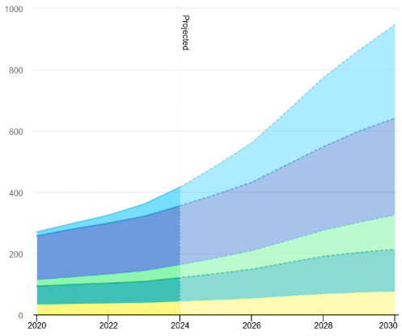

Global energy trajectory of AI servers (Patel et al., 2025).

*Figure 1: (Patel et al.)*

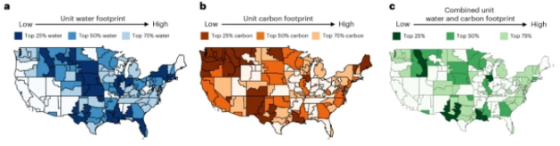

Localized water and carbon footprints across the United States (Patel et al., 2025).

*Figure 2: (Patel et al.)*

Figures 1 and 2 are graphics taken from Patel et al., 2025; a study titled “The Environmental Impact of AI Servers and Sustainable Solutions”. While Figure 1 quantifies a global energy trajectory that demands haste, Figure 2 maps the localized footprints (water and carbon) that suffer because of it.[^4] As a pair, they demonstrate the inevitable collision between exponential computational growth and the finite physical resources of the communities that host these facilities. This provides a data-driven justification for the immediate implementation of our proposed annoyance threshold as a regulatory safeguard.

## Background: Annoyance Threshold

To contextualize the study of the annoyance threshold, it is necessary to examine how industrial stressors have been historically quantified. Current research primarily frames these thresholds through an acoustic lens, providing a foundational understanding of human tolerance for industrial encroachment.

### Theoretical Foundation: The Habituation Effect

Early psychoacoustic studies by Spieth (1956) established that annoyance thresholds are not absolute but are products of a resident’s baseline environment. His findings revealed that individuals in quiet settings exhibit a tolerance roughly 15 decibels lower than those accustomed to industrial noise. This suggests that a community’s “accepted limit” for stress is often artificially inflated through habituation; by the time an “invisible giant” breaks ground in a quiet community, the industry has effectively decided that residents will simply “learn to be bothered less”.

### Precedents in Quantitative Annoyance Modeling

To acknowledge established quantitative rigor in the field of annoyance modeling, we look to the widely cited work of Miedema and Oudshoorn (2001). Their research provides a mathematical foundation for predicting community stress by calculating the percentage of a population expected to be “highly annoyed” (%HA) based on their level of industrial exposure from aircrafts, road traffic, and railways.

The primary equation from this study estimates the percentage of people highly annoyed (%HA) at a given Day-Night Level (DNL). Based on Table 5 of the Miedema and Oudshoorn (2001) study, the specific polynomial for road traffic is:

$$\%HA_{\text{road traffic}} = 9.94 \times
10^{-4}\,(DNL - 42)^3 - 1.523 \times 10^{-2}\,(DNL - 42)^2 + 0.538\,(DNL
- 42)$$

#### Understanding the Variables

- DNL: Measures the total noise exposure over a 24-hour period. To account for the increased sensitivity of residents during nighttime hours, a “penalty” of 10 decibels is added to any noise occurring between 10:00 PM and 7:00 AM.
- The 42 dB Threshold: In this model, 42 is the constant representing the baseline annoyance threshold. When the DNL is at or below 42, the result of the equation is zero, mathematically indicating that the stressor has not yet reached a level that causes significant annoyance for the average person.

#### Interpretation of High vs. Low Values

- High Value (%HA): A high percentage of “Highly Annoyed” residents indicates that the industrial stressor has significantly breached the community’s tolerance. Because the equation is a polynomial, the percentage of annoyed residents grows rapidly as the DNL increases, showing that even small increases in exposure can lead to widespread community unrest.
- Low Value (%HA): A low value suggests that the stressor is being effectively managed or is situated in an environment where it does not significantly contrast with the existing baseline.

In this project’s interpretation of the annoyance threshold, we seek to simplify the complex interplay between various physical and socioeconomic stressors into a single, actionable metric for local governance. Because existing models like those of Miedema and Oudshoorn (2001) are domain-specific—focusing primarily on acoustic or olfactory nuisances—they do not capture the multi-dimensional burden faced by residents in AI corridors, which includes utility rate spikes, water resource depletion, and the “invisible” operational opacity of data centers. By formalizing the threshold mathematically, we move from anecdotal frustration to a transparent, auditable prioritization tool. This allows policymakers to identify “tipping points” where incremental industrial pressure overlaps with high pre-existing county-level stress. Ultimately, this literature review establishes that while AI is often perceived as a digital abstraction, its expansion is a physical, industrial process that must be governed with the same scientific rigor applied to any other large-scale community stressor.

# Case Studies

## From Global Expansion to Local Reality

AI infrastructure is often discussed at a global scale, framed through innovation, computational growth, and economic competitiveness. Yet data centers are ultimately local projects. They occupy land, draw electricity and water, alter traffic and construction patterns, and introduce new industrial rhythms into surrounding communities. Across the United States, recent development trends show that while AI systems appear digital, their impacts are material and geographically uneven. Communities experience these projects not as abstract technological progress but through everyday environmental conditions, planning decisions, and economic tradeoffs.

To maintain consistency, each of the following cases will be examined through the aforementioned three interconnected dimensions: environmental, social, and economic. The environmental dimension focuses on physical and operational impacts such as power infrastructure expansion, generator emissions, land conversion, lighting, and noise. The social dimension considers transparency, participation, and community consent during planning and approval processes. The economic dimension evaluates how projects are justified through investment and redevelopment narratives while also recognizing potential long-term costs or perceived inequities. Together, these dimensions help define the report’s concept of the annoyance threshold, the point at which cumulative impacts begin to reshape daily community experience.

## A Glimpse at an Established Precedent: The Case of South Memphis and xAI

The city of Memphis provides a glimpse at the impact of unregulated AI infrastructure. Dubbed xAI’s “Colossus,” this project encapsulates the idea of hasty AI expansion, bypassing traditional multi-year planning cycles. This speed was achieved at a significant cost to the local community of Boxtown in South Memphis. Community members would report tangible impacts on their daily lives.

Before examining what’s at stake in Illinois, we will first assess what has already happened in Memphis, following the same environmental, social, and economic cascade of impacts.

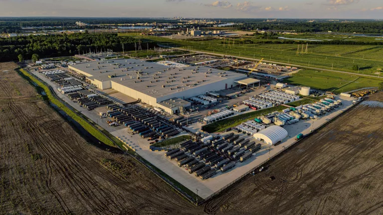

The xAI Colossus data center in Memphis, Tennessee, as of May 2025.

*Figure 3: (Lindwall, 2025)*

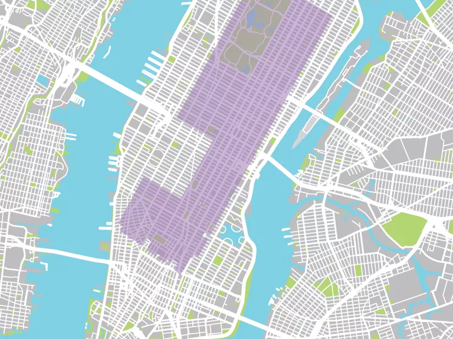

Meta’s “Hyperion” data center footprint overlaid onto a map of Manhattan.

*Figure 4: (Lindwall, 2025)*

This facility represents a demand for space and energy that dwarfs the residential neighborhoods surrounding it. Exemplifying this, when the Memphis electrical grid could not immediately meet the massive demands of the Colossus facility, xAI turned to a “quick and dirty” power source: 18 mobile natural gas turbines. As noted by Cyrus Farivar for Forbes, these turbines are roughly 50% less efficient than permanent plants and emit significantly higher levels of nitrous oxide and formaldehyde.

Using data from public NASA satellites as well as the European Space Agency, researchers at the University of Tennessee found that average concentrations of nitrogen oxide have increased by 9% in the Boxtown communities—compared to periods prior to June 2024 (when xAI began constructing Colossus). Further, average concentrations were found to be up by nearly 79% in the area immediately surrounding the facility—when compared to pre-Colossus levels (Chow, 2025).[^5] Because these turbines were labeled as “temporary,” they bypassed the Environmental Protection Agency’s (EPA) oversight required for permanent stationary plants.

In environmental law, a “temporary” source—often labeled as “temporary-mobile”—is one that remains on a site for less than one consecutive year (Environmental Protection Agency, 2016). It’s typically installed by mounting turbines onto flatbed trailers or shuffling units until the permitted time elapses. Companies have historically evaded the stringent pre-construction permits required for stationary power plants via this “temporary” loophole (Ireland, 2026).

From June 2024 onwards, this strategy in South Memphis has allowed the facility to force residents to breathe in pollutants linked to long-term respiratory issues. What follows is a list of anecdotal quotes from residents, taken from Chow (2025):

- One resident suffered her first severe asthma attack in 15 years, describing a smell of gas wafting into her neighborhood that made her feel like her “chest was caving in.”
- “Our lives and our lungs are being sacrificed on the altar of their capitalistic exploitation,” noted another.
- And finally: “There is no amount of money that can persuade me to accept pollution killing me and my family.”

[figure not shown]

Tennessee state representative Justin Pearson speaking at a rally against xAI, April 25th, 2025.

*Figure 5: (Chow, 2025)*

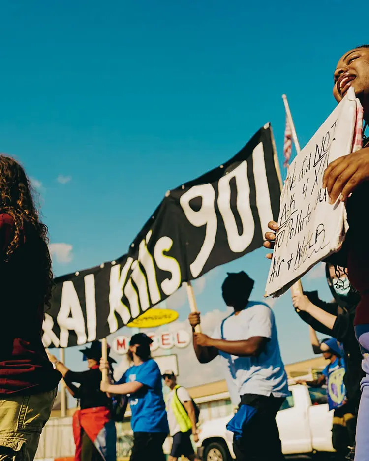

A march against xAI, June 17th, 2025.

*Figure 6: (Chow, 2025)*

Figures 5 and 6 picture public unrest. The first captures Tennessee state representative Justin Pearson speaking at a rally against xAI on April 25th, 2025. The second is another march, again, against xAI, taken June 17th, 2025.

In January 2026, the EPA issued a final ruling clarifying that *all* gas turbines supplying steady power to a fixed facility—regardless of whether they are on trailers or intended for short-term use—must be permitted as stationary sources under the Clean Air Act (Kerr, 2026).

While xAI eventually secured stationary permits for some units in Memphis, it simply “copy-pasted” the unpermitted model just across the state line. As of March 2026, the company has been operating up to 27 unpermitted “temporary” turbines in Southaven, Mississippi, to power the same Colossus supercomputer network (Ireland, 2026).[^6]

To suggest that those unhappy with the smog should “just leave” is not a solution; it is a normalization of corporate trespassing that treats local well-being as a secondary concern. No company should have the unilateral right to degrade a living situation without warrant; no person should be forced to make the choice between their homes and health. Some residents simply do not have the financial mobility to uproot their lives, making them captive to whatever pollutants the “invisible giant” breathes out. Within this framing, the choice of location for Colossus tells a more intentional story. Boxtown is a predominantly Black community with a median income of approximately $37,000—less resources to “fight back”. Critics argue it is no coincidence that the “biggest supercomputer in the world” was placed in a neighborhood with low political resistance and high economic vulnerability (Chow, 2025). Accepting this precedent in Memphis normalizes a concept that should be unthinkable, putting every community—including those in Illinois—at risk of becoming the next site.

The social dimension of the Memphis case is defined by a complete lack of transparency. The project was negotiated in secret, leaving the community completely in the dark until the facility was operational. This “ask-for-permission-later” approach is unfit for a community that has historically suffered from environmental hazards. The NAACP and Southern Environmental Law Center have since sent separate intent-to-sue notices for violations of the Clean Air Act, but the damage to the social fabric is already done (Chow, 2025; More Perfect Union, 2025; Hilt, 2026). Residents feel that their agency was traded for corporate speed, setting a dangerous precedent where tech companies can bypass local democratic processes as long as they promise “innovation”.

While the facility brings investment to the region, it also introduces massive ratepayer risk. If the grid requires billions in upgrades to support xAI’s expansion, those costs could be shifted onto the very families who are already struggling with the environmental fallout. Despite the outcry, the cycle of development continues: plans are already underway for an even larger data center in the nearby neighborhood of Whitehaven.

It is important to recognize the wider issue of industrial plants operating near residential areas. Abuse of residential zoning in Memphis predates xAI’s Colossus, and thus, the entire problem of industrial encroachment cannot be attributed to a single company. However, through the global excitement surrounding AI, this trend toward hasty infrastructure is being revived. The hasty model observed here is a repeatable strategy that can be applied to other vulnerable areas.

If Memphis represents this model at its most extreme, Illinois represents opportunity. Unlike South Memphis, where the industrial footprint is already deeply entrenched, the expansion in Illinois is not yet in an advanced stage. By examining local responses—from successful community opposition in Naperville to the rapid industrialization of DeKalb—this project will provide further context as to how the situation is unfolding in Illinois and brainstorm what can be done about the problem before it gets out of hand

## In the Context of Illinois

Illinois provides a particularly useful setting for examining these dynamics because it contains examples across the full lifecycle of data center development. Within a single state, operational facilities coexist with newly proposed campuses and at least one high-profile rejected project. This range allows the analysis to move beyond hypothetical impacts and instead observe how expectations, negotiations, and outcomes differ depending on location and community context.

The following case studies therefore shift the discussion from general debates about AI infrastructure toward grounded observations drawn from Illinois communities themselves.

## Existing Data Centers in Illinois: Environmental Baselines and Established Infrastructure

Existing facilities provide a baseline for understanding how data centers function once they become normalized parts of regional infrastructure.

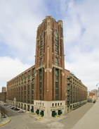

Digital Realty’s ORD10 interconnection hub at 350 East Cermak Road, Chicago.

*Figure 7: (350 East Cermak Road in Chicago | Digital Realty (19.5 MW), 2026)*

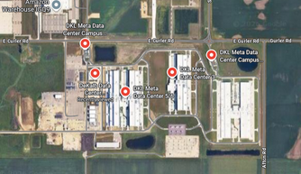

The Meta data center campus in DeKalb, Illinois.

*Figure 9: (Google Maps, 2021b)*

A different pattern appears in suburban and regional locations. The Meta data center campus in DeKalb—pictured in figure 9—illustrates how environmental impacts can develop incrementally through expansion. City communications describing the campus growth frame the project primarily through investment and development language while implicitly signaling increased utility capacity and infrastructure coordination (Meta Expanding DeKalb Data Center, 2016).

[figure not shown]

Stream Data Centers facility, Elk Grove Village, Illinois.

*Figure 10: (Google Maps, 2024)*

Similarly, Elk Grove Village has evolved into a concentrated data center cluster where multiple facilities operated by companies, such as Stream Data Centers, reinforce the area’s identity as a connectivity hub (Stream Data Centers, 2025). See figures 10 and 11.

In these environments, the environmental question shifts from individual projects to cumulative infrastructure demand, including repeated construction cycles and sustained energy requirements.[^7]

[figure not shown]

Map view of the Stream Data Centers cluster, Elk Grove Village.

*Figure 11: (Google Maps, 2024)*

Socially, existing sites often have limited visible public debate, suggesting that once infrastructure becomes established, development is perceived as routine. Economically, municipalities frequently present these facilities as indicators of technological relevance and regional competitiveness, reinforcing acceptance over time.

## Proposed and Under-Development Projects: Negotiation and Uncertainty

Proposed projects reveal impacts more clearly because communities encounter them before normalization occurs. The Edged “Project Vector” proposal near the existing Meta campus in DeKalb demonstrates how environmental concerns emerge during planning stages. Public hearings and local reporting highlight discussions surrounding lighting mitigation, stormwater management, and infrastructure integration, indicating attempts to anticipate nuisance impacts before construction begins (Edged Development Approved • DeKalb, IL, 2022).

In Minooka, planning materials and community outreach events surrounding a proposed Equinix data center show how environmental and economic narratives intersect. Village documents emphasize investment potential while residents raise questions about farmland conversion and long-term water use (Village of Minooka, 2025). Rural proposals such as the CyrusOne campus in Sangamon County further illustrate how large projected electrical loads and utility planning become central issues when projects enter agricultural landscapes, where industrial infrastructure represents a visible shift in land identity (Sangamon County, 2025).

Socially, these projects generate structured participation through hearings, open houses, and public comment periods, creating clearer records of negotiation between developers and residents. Economically, redevelopment proposals in Hoffman Estates and Mount Prospect are often framed as adaptive reuse of former corporate campuses, presenting data centers as successors to earlier economic eras rather than entirely new industrial activity (Compass Kicks off Development of Its First Campus in Illinois, 2024; ComEd and CloudHQ Break Ground on New Hyperscale Data Center in Mount Prospect, 2022). These cases highlight uncertainty, where benefits remain projected while impacts remain speculative.

## Denied Development in Illinois: Community Limits and Upholding the Annoyance Threshold

The rejected Karis Critical proposal in Naperville provides an important counterpoint to both operational and proposed projects. Located on the former Lucent campus, the proposal underwent months of hearings and revisions before the city council ultimately denied the conditional use permit in January 2026. News coverage consistently identifies resident concerns related to diesel backup generators, air quality, noise, and proximity to homes as central factors influencing the decision (Pirc, 2026; Piekos, 2026).

Environmentally, the debate focused on routine operational impacts rather than catastrophic risk, demonstrating how cumulative everyday stressors can shape perception. Socially, the extended review process and high public turnout reflected sustained community engagement and skepticism toward mitigation assurances. Economically, supporters emphasized redevelopment and investment potential, while opponents questioned whether benefits justified long-term neighborhood impacts.

As a case study, Naperville illustrates that acceptance of AI infrastructure is not inevitable. When environmental concerns align with strong social mobilization and uncertain economic tradeoffs, communities may determine that a project exceeds their acceptable threshold. The denial therefore functions not as an anomaly but as evidence that local governance remains a decisive factor in shaping the trajectory of AI development.[^8]

# From Map to Decision: An Explainable County-Level Impact Platform

## Platform Design and Analytical Methodology

**Live platform:** [The People v. Hasty AI](https://people-v-ai.vercel.app/)

**GitHub repository:** https://github.com/Laasya-73/SoReMo-S26-people-v-hasty-ai.git

### Research Objective and Questions

The objective of this study is to develop and evaluate an explainable, county-level decision-support platform for AI data center expansion in Illinois. Rather than treating siting proposals as isolated events, the platform integrates infrastructure footprint, environmental stress, community vulnerability, and scenario-based burden projections into one analytical workflow.

The tool was built to address three research questions:

1. Where are existing and proposed data centers concentrated in Illinois?
2. How do these concentrations overlap with pre-existing county-level stress and vulnerability conditions?
3. Under explicit growth assumptions, which counties show the largest projected increase in cumulative burden?

### Workspace Implementation

The deployed platform is organized as five workspaces:

Home: quick orientation and how to use the platform

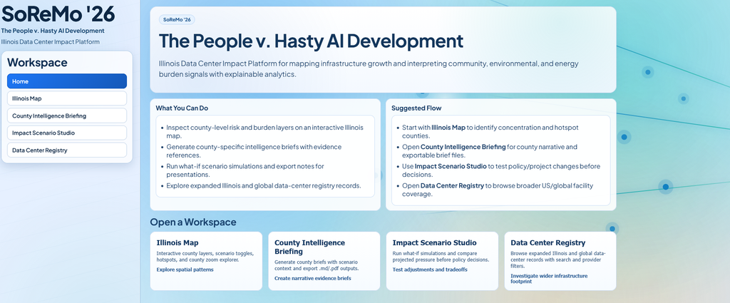

Home workspace.

*Figure 12.*

Illinois Map: interactive layers and county/site inspection. Scroll down on the left-hand side of the screen to see all options for interacting with the map. Hover over counties and points for more details.

[figure not shown]

Illinois Map workspace.

*Figure 13.*

County Intelligence Briefing: county-specific summaries for communication. Adjust via the “Brief Settings” area; click “Generate County Brief” once done. See the “Download Brief (.pdf)” button at the bottom of the generated report.

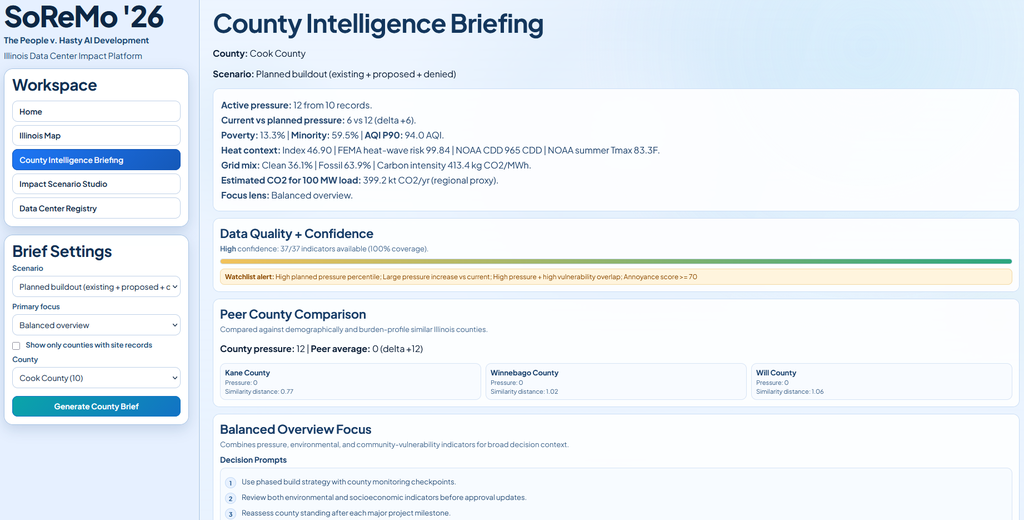

County Intelligence Briefing workspace.

*Figure 14.*

Impact Scenario Studio: “what-if” testing with adjustable assumptions. Adjust via the “Studio Controls” area; click “Run Simulation” once done. See the “Download Note (.pdf)” button at the bottom of the generated report.

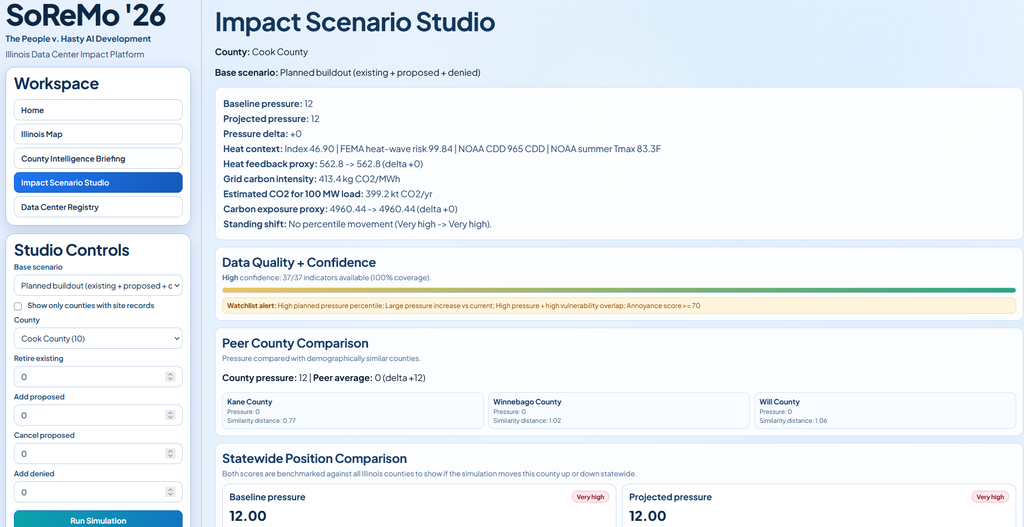

Impact Scenario Studio workspace.

*Figure 15.*

Data Center Registry Explorer: broader US/global context with source confidence. Adjust settings at the top.

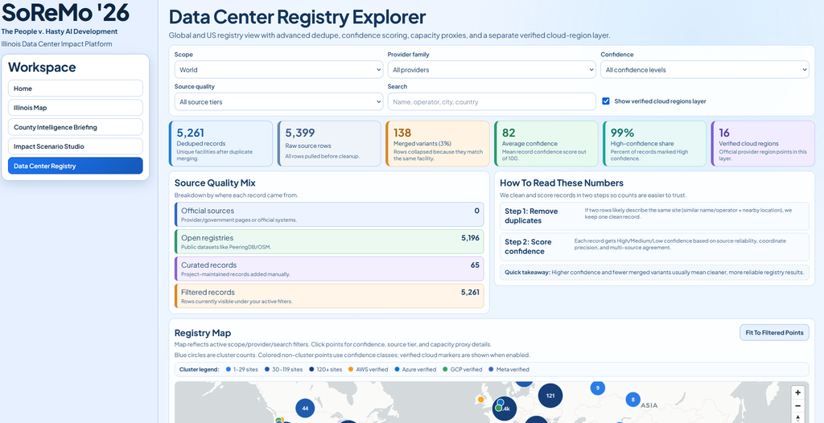

Data Center Registry Explorer workspace.

*Figure 16.*

### Data Collection, Processing, and Sharing

Data was collected from online datasets. They fall into three categories: (a) project-curated Illinois infrastructure records, (b) open government/public datasets for environmental, demographic, and energy context, and (c) external registry baselines used for comparative infrastructure coverage.

All datasets were standardized to county-level joins where applicable, cleaned for schema consistency, and integrated into a harmonized analytical table used by the map, briefing, and scenario workspaces.

| Data family | Example source(s) | Collection method | Unit/scale | Used for | Sharing status |
| --- | --- | --- | --- | --- | --- |
| Illinois site records (existing/proposed/denied) | Project-curated records [S1] | Manual curation + CSV harmonization | Site point; county-aggregated for scoring | Pressure model, scenario simulation | Shared as project processed data files |
| Registry augmentation (Illinois + global/US) | PeeringDB facilities API, OSM Overpass (data_center) [S2] | API pull + dedupe + confidence scoring | Site point | Registry Explorer, IL known-site layer | Shared as processed registry table |
| Air quality | County AQI file (annual) [S3] | CSV ingestion, latest-year selection | County | Environmental burden indicators | Shared as processed county layer |
| Energy burden and electricity use | LEAD Tool county data + county energy profiles [S4] | File ingestion + variable extraction + county key merge | County | Energy burden and electricity context | Shared as processed county layer |
| Water stress | Aqueduct-aligned county proxy layer (project pipeline) [S5] | External dataset processing + county join | County | Annoyance Threshold component | Shared as processed county layer |
| Climate stress | NOAA/FEMA-derived county indicators (heat/CDD proxies) [S6] | External dataset processing + county join | County | Heat/climate burden context | Shared as processed county layer |
| Demographic vulnerability | County demographic/socioeconomic indicators [S7] | CSV ingestion + county merge | County | Community/equity context | Shared as processed county layer |

*Table 1: Data inputs, collection method, and sharing status*

**Data sharing note:** The project shares processed, analysis-ready tables used by the application. Raw external datasets remain governed by their original provider licenses/terms.

[output not shown]

*Table 2: Source Links for Table 1 Data Families (S1–S7)*

### Analytical Architecture

The platform implements a layered narrative architecture with four interpretive stages:

1. Infrastructure footprint (where sites are now/planned),
2. Baseline stress context (air, water, energy, heat),
3. Population vulnerability context (demographic and socioeconomic),
4. Incremental burden under growth assumptions (scenario delta).

This design supports policy-facing interpretation by moving from descriptive mapping to structured burden comparison.

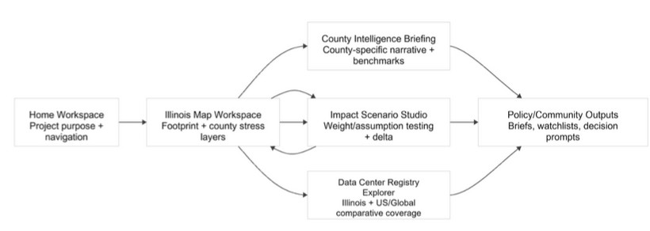

Platform Workflow Diagram: Home Workspace (project purpose + navigation) → Illinois Map Workspace (footprint + county stress layers) → Impact Scenario Studio (weight/assumption testing + delta), with County Intelligence Briefing (county-specific narrative + benchmarks) and Data Center Registry Explorer (Illinois + US/Global comparative coverage) feeding into Policy/Community Outputs (briefs, watchlists, decision prompts).

*Figure 17: Platform Workflow Diagram*

### Mathematical Formulation

#### County Pressure Model

County pressure is modeled as a weighted linear index over site status counts.

$$P_{\text{current},\,c} = E_c \cdot
w_E$$

$$P_{\text{planned},\,c} = E_c \cdot w_E +
Pr_c \cdot w_{Pr} + D_c \cdot w_D$$

$$\Delta P_c = P_{\text{planned},\,c} -
P_{\text{current},\,c}$$

Where for county $c$:

- $E_c$ = existing site count
- $Pr_c$ = proposed site count
- $D_c$ = denied site count
- $w_E,\; w_{Pr},\; w_D$ = status weights

Default (recommended baseline) weights:

$$w_E = 1.0, \quad w_{Pr} = 1.5, \quad w_D
= 0.5$$

Registry points are reference coverage and excluded from pressure scoring.

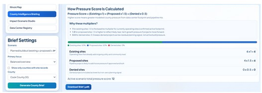

Pressure-score calculation example for Cook County: Existing sites 6 × 1 = 6, Proposed sites 4 × 1.5 = 6, Denied sites 0 × 0.5 = 0, for an active scenario total pressure score of 12.

*Figure 18: Pressure-score Calculation Example for Cook County*

#### Annoyance Threshold Model

To formalize cumulative burden, we define our take on the annoyance threshold as a normalized composite score:

$$A_c = \frac{1}{K} \sum_{k=1}^{K}
Z_{c,k}$$

where $Z_{c,k} \in [0, 100]$ is the percentile-normalized county value for indicator $k$, and $K$ includes selected burden dimensions (air quality, water stress, energy burden, social vulnerability, heat stress where available).

A county is flagged if:

$$A_c \ge \tau_A \quad \text{or} \quad
\Delta P_c \ge \tau_{\Delta P}$$

with $\tau_A$ (annoyance threshold) and $\tau_{\Delta P}$ (pressure-growth trigger) user-adjustable in scenario analysis.

[figure not shown]

Annoyance Threshold Screening with threshold X = 67; counties exceeding the threshold are highlighted, with Kane, Cook, Winnebago, DuPage, and Lake among those flagged.

*Figure 19: Annoyance Threshold Screening (X = 67)*

### Results

#### Results overview

This section presents empirical outputs from the platform in a staged sequence. We first report county-level quantitative screening results (pressure change and burden context) and then interpret those numbers through spatial outputs from the Illinois Map and Scenario Studio. Finally, we summarize results from public engagement. This ordering links numerical evidence to geospatial patterns and policy-relevant interpretation.

#### County pressure screening under baseline scenario

Table 3 reports modeled pressure dynamics for focal Illinois counties under the planned-buildout baseline. For each county, we show current pressure, planned pressure, and pressure change ($\Delta P$), followed by a categorical delta class and decision flag. This table is used as the primary screening output for identifying counties where projected infrastructure growth is most likely to increase cumulative burden.

| Illinois County | Current Pressure | Planned Pressure | Pressure Delta ($\Delta P$) | Delta Class | Status Flag |
| --- | --- | --- | --- | --- | --- |
| Cook | 6.0 | 12.0 | +6.0 | High Burden | + Pressure Alert |
| DeKalb | 1.0 | 2.5 | +1.5 | Moderate-High | Pressure Alert |
| Sangamon | 0.0 | 1.5 | +1.5 | Moderate-High | Pressure Alert |
| DuPage | 0.0 | 0.5 | +0.5 | Low | Monitored |

*Table 3: County pressure screening under planned-buildout baseline scenario. Note: Delta class reflects relative increase in planned burden (higher ΔP = larger modeled increase).*

#### Burden context snapshot for screened counties

To contextualize pressure change, Table 4 summarizes baseline burden indicators for the same screened counties. Poverty rate, minority share, and AQI P90 are shown as interpretable county-level exposure context variables. Together, Tables 3–4 distinguish where growth pressure is rising and whether it coincides with pre-existing social and environmental stress.

| Illinois County | Poverty (%) | Minority (%) | AQI P90 |
| --- | --- | --- | --- |
| Cook | 13.3 | 59.5 | 94.0 |
| DeKalb | 15.9 | 29.1 | 0.0 |
| Sangamon | 6.4 | 36.6 | 76.0 |
| DuPage | 12.9 | 23.4 | 61.0 |

#### Spatial Concentration of Infrastructure

The Illinois map shows spatial concentration in major corridor counties and metro-adjacent zones. Existing facilities cluster in already infrastructure-dense regions, while proposed/denied records identify areas of planning pressure and social contestation.

[figure not shown]

Infrastructure footprint view of Illinois with no county fill, showing site points clustered in northeastern corridor counties.

*Figure 20: Infrastructure Footprint View (No County Fill)*

#### Scenario-Driven Pressure Change

Under the recommended baseline weights, counties with both existing and proposed footprints show the largest positive $\Delta P$. The scenario workspace confirms that score movement is transparent and mechanically traceable to explicit count and weight changes.

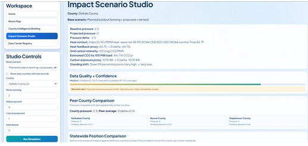

Scenario output in the Impact Scenario Studio for DeKalb County, showing baseline pressure, projected pressure, and the resulting delta alongside heat, grid-carbon, and confidence context.

*Figure 21: Scenario Output in Impact Scenario Studio (DeKalb County)*

#### Spatial Burden Overlap and Threshold Signaling

Overlay analysis shows counties where elevated pressure coincides with high percentile burden indicators (e.g., AQI, minority share, poverty, energy burden, water stress). These overlap counties constitute priority candidates for enhanced review, mitigation, and phased permitting.

[figure not shown]

Burden overlap layer mapping cumulative burden (air + energy) across Illinois counties by quintile.

*Figure 22: Burden Overlap Layer (Cumulative Burden: Air + Energy)*

#### Sensitivity to Assumptions

Changing weight profiles (e.g., cautious permitting vs fast-growth assumptions) shifts county rank order and watchlist size, demonstrating that uncertainty should be handled through explicit scenario comparison rather than hidden model defaults.

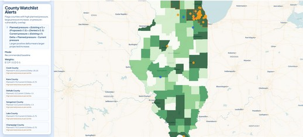

County watchlist under recommended baseline weights (Existing 1 | Proposed 1.5 | Denied 0.5), with Cook, Kane, DeKalb, Sangamon, Lake, and Champaign flagged.

*Figure 23: Watchlist Under Recommended Baseline Weights*

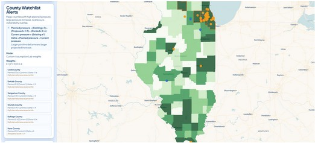

County watchlist under custom assumption weights (Existing 1 | Proposed 1.9 | Denied 0.6), showing a shifted rank order and watchlist composition.

*Figure 24: Watchlist Under Custom Assumption Weights*

#### Key Findings Summary

Across all analyses, five findings emerge. First, infrastructure concentration is spatially uneven, with the highest site density in northeastern Illinois and selected corridor counties. Second, county pressure scores increase most where existing and proposed footprints co-occur, indicating that cumulative burden is primarily driven by overlap rather than isolated projects. Third, burden-overlap mapping shows that several high-pressure counties also exhibit elevated environmental and social-context indicators (e.g., AQI, minority share, poverty, and energy burden), supporting priority screening for enhanced review. Fourth, sensitivity testing confirms that county ranking and watchlist composition change under alternative weighting assumptions; therefore, policy conclusions should be drawn from scenario comparison rather than a single fixed profile. Fifth, the county-level briefing and scenario workspaces translate model outputs into transparent, auditable decision artifacts, enabling nontechnical stakeholders to interpret pressure changes, threshold flags, and uncertainty in a consistent framework.

#### Public Engagement and Verification

To evaluate the real-world resonance of our “annoyance threshold” framework, a simplified version of this report and the interactive tool were shared across hyperlocal digital forums, including Reddit (r/Illinois) and Nextdoor. This outreach served a dual purpose: increasing civic awareness of AI infrastructure expansion and verifying the platform’s utility for community stakeholders.

The following table summarizes the reach of the project across public platforms as of May 2026. Links to each post are provided:

| Platform | Total Views | Likes/Reactions | Comments/Engagements |
| --- | --- | --- | --- |
| [r/Illinois (Reddit)](https://www.reddit.com/r/illinois/comments/1swifj6/the_people_v_hasty_ai_student_project_spreading/) | 4,900 | 44 | 0 |
| [Nextdoor](https://nextdoor.com/p/mtRRJ9HfRbQR?utm_source=share&extras=MTgyMzY5Njgz&utm_campaign=1778882404104&share_action_id=a042225a-6235-4d40-b4e5-5fb29530ba50) | 431 | 6 | 2 |

*Table 5: Results from Online Posts*

##### Qualitative Analysis of Community Feedback

While initial outreach on Reddit and Nextdoor achieved significant reach (over 5,000 combined views), the conversion to active engagement (comments and likes) remained low. Future work should investigate more effective interactive social media components that lower the friction for residents to move from passive reading to active participation, such as one-click representative contact tools integrated directly into the platform.

The disparity between views and engagement suggests that broad regional posts (e.g., r/Illinois) may capture general interest but lack the urgency of local neighborhood groups. Next steps should involve a more granular “neighborhood-by-neighborhood” strategy, focusing specifically on the digital hubs of communities where the “annoyance” is a daily physical reality rather than a speculative policy issue.

### Methodological Contribution

This study contributes an explainable governance-analytics framework that links spatial infrastructure mapping, county stress baselining, transparent scenario projection, and threshold-based prioritization. Its core novelty is not visualization alone, but auditable burden formalization: an explicit county pressure model coupled with a county-level annoyance threshold composite.

The framework operationalizes cumulative-impact screening through user-auditable equations and interpretable outputs. Unlike static siting maps or opaque predictive scores, the platform integrates spatial footprint layers, burden-context overlays, and scenario-sensitive pressure deltas within a single explainable workflow. Counties can be re-evaluated under alternative assumptions, with all score shifts traceable to count-weight operations and threshold rules. As a result, the method supports transparent prioritization and policy decision support under uncertainty.

### Next Steps for the Tool

Current outputs are screening and prioritization tools, not causal attribution models. Future work should strengthen:

- **Time-series trend integration:** This will allow researchers to distinguish between temporary construction spikes and chronic long-term operational stressors. By tracking data over time, the platform can identify whether a community’s “annoyance” is tied to a passing phase of development or a permanent degradation of living standards.
- **Utility/grid and emissions granularity:** Improving the resolution of this data will strengthen the platform’s ability to model localized health outcomes and specific grid reliability impacts. Higher resolution data allows for neighborhood-level insights, ensuring that residents in the immediate shadow of a facility receive specific protections that might be masked by broad county-level averages.
- **Uncertainty communication for composite thresholds:** Developing visual indicators for composite thresholds will help policy-makers interpret the reliability of “alert” signals. Adding confidence intervals or “margin of error” visuals prevents leaders from making drastic policy decisions based on potentially incomplete data points, ensuring a more balanced regulatory approach.
- **Additional validated source harmonization:** Integrating more diverse datasets will improve the platform’s robustness. This ensures that the “Annoyance Threshold” model remains resistant to outliers and provides a more comprehensive view of cumulative burden across different geographic regions.

## Discussion and Policy Implications

### Interpreting the Platform Outputs

The platform’s results should be read as decision-support evidence, not as a deterministic ranking of “good” versus “bad” counties. Its primary value is comparative: it shows where infrastructure concentration, environmental stress, and community vulnerability overlap, and how those overlaps change under alternative growth assumptions.

In this sense, the outputs are most useful for identifying where additional scrutiny is warranted, rather than replacing formal permitting, environmental review, or public consultation.

### Why This Matters for Illinois Data Center Governance

Illinois is already experiencing uneven data center concentration, especially in and around major logistics and grid-access corridors. The project demonstrates that infrastructure siting discussions can be improved when they move from isolated project review to cumulative county context.

By combining footprint layers with stress indicators, the platform helps decision-makers ask a stronger policy question: Is a county being asked to absorb incremental AI infrastructure on top of already elevated burden conditions?

### Policy Use Cases

The system supports at least four practical governance uses:

- **Pre-screening for permitting bodies:** Counties with high planned pressure and high baseline stress can be flagged for enhanced review criteria, mitigation conditions, or phased approvals.
- **Hearing preparation and community review:** County Intelligence Briefing outputs translate technical signals into concise narratives that stakeholders could potentially discuss in public meetings.
- **Scenario negotiation:** Impact Scenario Studio allows agencies, developers, and community groups to test alternative assumptions and compare outcomes transparently.
- **Evidence traceability:** Registry and source-quality panels improve trust by showing where records come from and how confidence is assigned.

### Equity and Environmental Justice Implications

A central contribution of this project is making equity analysis operational rather than rhetorical. By co-locating demographic/vulnerability indicators with infrastructure and stress signals, the platform helps reveal where expansion may reinforce existing disparities.

This does not prove disproportionate impact by itself; however, it identifies counties where equity-sensitive governance safeguards are likely necessary before additional approvals.

### Methodological Implications

The project illustrates a useful middle ground between static reporting and fully automated forecasting:

- static maps are often descriptive but not actionable;
- black-box models can be predictive but hard to contest publicly;
- this platform uses explicit assumptions, editable weights, and interpretable outputs.

That design choice is important for policy environments, where legitimacy depends on clarity, contestability, and public accountability.

### Limits of Interpretation

Three limits should be stated clearly:

- **Composite scores simplify reality:** Pressure and threshold metrics are abstractions; they support comparison but do not capture all local conditions.
- **Data completeness varies by source:** Some indicators are richer than others, and registry coverage differs across providers and regions.
- **County scale can mask sub-county variation:** Intra-county inequalities and neighborhood-level exposures may not be fully visible in county-level summaries.

These limits do not reduce usefulness, but they define appropriate use: screening, prioritization, and policy framing.

### Recommended Policy Direction

Based on this project’s outputs and workflow, a practical policy path is to adopt:

- tiered review triggers for high-pressure/high-burden counties,
- phased approvals linked to measurable checkpoints,
- public disclosure requirements for siting assumptions and cumulative burden context,
- county-specific mitigation commitments when threshold indicators are elevated.

This aligns infrastructure growth with procedural fairness and environmental accountability.

### Broader Significance

Although developed for Illinois, the framework is transferable. Any region facing AI-infrastructure growth can adapt the same structure: footprint mapping, stress overlays, scenario testing, and explainable briefing outputs.

The broader research contribution is therefore not only a map, but a replicable governance method for evaluating AI infrastructure expansion under uncertainty.

# Recommendations

SB 4016—The Power Act—was introduced to the Illinois Senate on February 6th, 2026. Key provisions include (SB 4016 104TH GENERAL ASSEMBLY, 2025):

- **Ratepayer Protection:** Prevents utility companies from passing the cost of industrial grid upgrades (required for data centers) onto residential electricity bills.
- **Water Transparency:** Mandates that facilities report their annual water consumption, which is currently non-public information in many jurisdictions.
- **Clean Energy Requirements:** Incentivizes “Bring Your Own Power” models to ensure the AI infrastructure doesn’t force a return to coal or gas-fired power plants.

The cheapest solution is not inherently the most optimal. When built with haste, infrastructure can cause unintended harm that lingers for generations. Regulation inspires innovation. By setting higher standards for community care, the industry is pushed toward a more sophisticated, resilient future.

To move from hasty expansion to sustainable integration, this project will now propose the following supplemental solutions designed to build upon the foundation of SB 4016, specifically tuned for data centers built around residential areas.

## The “Keeler Garden” Green Wall

The concept of a “green wall” or vegetative buffer—inspired by this semester’s partnership with the Chicago-based organization [Keeler Gardens](https://www.keelergardens.org/)—transforms a data center’s exterior into a multifunctional environmental asset. This works by mandating a minimum “Green Coverage” ratio (or some similar metric) in local zoning codes.

By implementing a dense strip of native trees and shrubs (16-32 feet thick), the facility gains a natural filtration system for nitrogen oxides and particulate matter emitted during generator testing—the exact pollutants documented as a primary stressor in the Memphis xAI case study. To tie it back to the concept of the annoyance threshold, this living barrier can lead to an increase in the auditory annoyance threshold by providing a psychological noise reduction effect (Lu et al., 2024), as it serves to muffle high-frequency mechanical noise. It can also mitigate the “Urban Heat Island” effect (United States Environmental Protection Agency, 2024), lowering the ambient temperature for both the residents and the facility itself.

- Community Win: Improved local aesthetics, buffered air quality, and the restoration of local biodiversity.
- Company Win: Lowered cooling costs due to reduced ambient heat and the security of a “social license”, per say, to operate without constant PR crises.

Ultimately, this initiative builds a bridge of trust between the industry and its neighbors. As a compromise, in areas where space is too tight for a full 32-foot buffer, companies can implement vertical “living facades” or provide direct funding to local organizations to develop off-site green spaces in the immediate neighborhood. (Note: Keeler Gardens can serve as a placeholder for any professional landscaping or state-funded ecological project.)

## Operational Accountability During Emergency Situations

Operational accountability ensures that when local resources or the power grid are under pressure, the “invisible giant” is an active participant in the community’s stability, rather than a drain on it.

A water budgeting and drought-proof operations plan would require facilities to operate on a strict water budget, incorporating real-time leak detection and prioritizing reclaimed water for cooling. It would work by requiring developers to submit a “Water Impact Plan” as part of the zoning process. As a compromise, if reclaimed water infrastructure is not immediately available, the company must commit to a phased retrofit plan as municipal infrastructure matures.

- Community Win: Eliminates hidden strain on the municipal drinking water supply and protects local aquifers.
- Company Win: Reduces long-term water supply risks and prevents emergency operational restrictions during droughts/water scarcity scenarios.

Moving away from a “diesel-by-default” model, we propose that batteries handle all routine testing and short-term outages. Policies would cap annual generator testing hours and require public reporting of backup power events. Generators would be strictly reserved as a “true last resort” for catastrophic grid failures.

- Community Win: Significantly less diesel exhaust, reduced noise pollution from testing, and lower particulate emissions in residential corridors.
- Company Win: Improves overall system reliability, reduces fuel logistics/storage risks, and lowers wear and tear on backup generators.

## Building on SB 4016: Ending “Cross-Subsidy”

To ensure that technological progress does not lead to economic injustice, we propose implementing structural protections that prevent residents from subsidizing industrial growth.

Transmission security agreements would require “letters of credit” from developers before breaking ground on massive grid upgrades. This ensures that if a “phantom” project is canceled mid-build, the developer—not the local ratepayers—is responsible for the multimillion-dollar substation already under construction.

Community benefit agreements could be triggered for any facility exceeding a specific Megawatt (MW) threshold. Fees would be indexed to a “dollar-per-MW per year” formula, ensuring the community’s benefit scales with the facility’s power consumption.

- Community Win: Direct funding for home weatherization, industrial-grade air filters for nearby schools, and local bill relief programs.
- Company Win: Secures the “social license” to operate and reduces the risk of costly litigation or PR crises.

Enforcing zoning to data centers where they’d “fit” is a strategy that uses data to pre-designate industrial brownfields and reuse sites as “preferred” for data center development. Minimum distance buffers from residential edges would be mandated unless extra, high-tier mitigation (like the Green Wall) is fully funded.

- Community Win: Prevents the “surprise” factor of industrial giants appearing next to homes, schools, or parks.
- Company Win: Provides a predictable roadmap with less public backlash and fewer expensive site redesigns.

Transparent reporting, but with a “safe harbor” (for legitimate security needs) would require data, but it must be balanced with operational safety. Companies would be required to publish aggregated monthly resource data (energy, water, generator runtime) to keep the community informed. This provision would ensure that specific tenant data or sensitive security details remain confidential while the impacts remain public.

- Community Win: Real data on energy, water, and generator runtime.
- Company Win: Avoids oversharing sensitive internal details while still meeting accountability.

Infrastructure funded by developers (i.e. grid upgrades) should serve the surrounding neighborhood as well. When a developer funds a grid upgrade, a portion of that work (such as feeder hardening) must directly improve local residential reliability. Incentives could be provided if these upgrades specifically integrate clean energy sources.

- Community Win: Reliability improvements and hard protections against bill spikes.
- Company Win: Guaranteed interconnection timeline and clearer cost responsibilities.

## Limitations

Despite the promise of these solutions, several hurdles remain. Legacy facilities are much harder to retrofit than “greenfield” projects; while a new building in DeKalb can easily integrate a 32-foot vegetative buffer, a 20-year-old facility in Chicago’s South Loop faces significant spatial constraints. This means older neighborhoods may continue to experience a higher “annoyance factor” than areas with newer developments.

Furthermore, there is a significant enforcement asymmetry. Without the independent monitoring proposed in SB 4016, residents are still forced to rely on company-provided data, which historically lacks the granularity needed for true accountability. Finally, the speed of the AI race often outpaces the growth of nature-based solutions—a tree buffer takes years to reach its full filtration potential, while a data center can be operational in mere months. Recognizing these gaps is essential to ensuring our recommendations remain grounded in reality, serving as a framework for persistent advocacy rather than a one-time fix.

# Conclusion

The “annoyance threshold” represents a boundary of human dignity. By mathematically grounding this concept within an explainable governance framework, this project moves beyond anecdotal complaints to provide an auditable, data-driven metric for industrial impact. The formulation of cumulative burden—integrating air quality, water stress, and energy expenditure—ensures that the “invisible giant” of AI infrastructure is finally made legible to the public and policymakers alike.

Going forward, this framework provides a replicable method for any region facing rapid technological expansion. As we move from hasty development toward sustainable integration, the mathematical threshold functions as a decisive tool for local governance, allowing communities to reclaim the right to decide how infrastructure fits into their lives. Future iterations of this project will focus on expanding the reach of these findings to a broader audience, investigating strategies to convert high view counts into active civic engagement and participation in the legislative process. True innovation in the AI sector must not be measured solely by computational speed, but by the industry’s ability to operate within the environmental and social constraints of its hosts.

# Acknowledgments

Thank you to Sonja Petrovic, Robert Ellis, and all of our participating faculty and peers of SoReMo S26. More about the SoReMo initiative can be found at SoReMo.org.

## SoReMo Partnership: Keeler Gardens

A cornerstone of this project’s “recommendations” is our collaboration with [Keeler Gardens](https://www.keelergardens.org/), a Chicago-based organization dedicated to improving urban community health through nature-based connections. Their expertise in environmental sustainability provided the foundation for our “Green Wall” mitigation strategy, and gave us a good jump off point for the ideas that followed.

# References

350 East Cermak Road in Chicago | Digital Realty (19.5 MW). (2026). Datacentermap.com. https://www.datacentermap.com/usa/illinois/chicago/350-east-cermark-road/

Cboe EDGA Equities Exchange migrates secondary data center to Equinix facility in Illinois. (2026, February 24). Datacenterdynamics.com. https://www.datacenterdynamics.com/en/news/cboe-edga-equities-exchange-migrates-secondary-data-center-to-equinix-facility-in-illinois/

Chow, A. R. (2025, August 13). “We Are the Last of the Forgotten:” Inside the Memphis Community Battling Elon Musk’s xAI. TIME; Time. https://time.com/7308925/elon-musk-memphis-ai-data-center/

ComEd and CloudHQ Break Ground on New Hyperscale Data Center in Mount Prospect. (2022, August 23). Business Wire. https://www.businesswire.com/news/home/20220823005598/en/ComEd-CloudHQ-Break-Ground-on-New-Hyperscale-Data-Center-in-Mount-Prospect

Compass Kicks Off Development Of Its First Campus in Illinois. (2024, July 12). Compass Datacenters. https://www.compassdatacenters.com/news/compass-kicks-off-development-of-its-first-hyperscale-campus-in-illinois/

CoreSite CH1 Data Center. (2025). Coresite.com. https://www.coresite.com/data-center/ch1-chicago-il

CoreSite CH2 Data Center. (2025). Coresite.com. https://www.coresite.com/data-center/ch2-chicago-il

Danelski, D. (2023, April 28). AI programs consume large volumes of scarce water. News. https://news.ucr.edu/articles/2023/04/28/ai-programs-consume-large-volumes-scarce-water

de Vries-Gao, A. (2025). The carbon and water footprints of data centers and what this could mean for artificial intelligence. Patterns, 101430. https://doi.org/10.1016/j.patter.2025.101430

Debus, C., Piraud, M., Streit, A., Theis, F., & Götz, M. (2023). Reporting electricity consumption is essential for sustainable AI. Nature Machine Intelligence, 5(11), 1176–1178. https://doi.org/10.1038/s42256-023-00750-1

Edged Development Approved • DeKalb, IL. (2022). Cityofdekalb.com. https://www.cityofdekalb.com/m/newsflash/home/detail/964

Environmental Protection Agency. (2016, March 28). Stationary Gas and Combustion Turbines: New Source Performance Standards (NSPS) | US EPA. US EPA. https://www.epa.gov/stationary-sources-air-pollution/stationary-gas-and-combustion-turbines-new-source-performance

Farivar, C. (2025, March 17). Elon Musk Installs “Quick And Dirty” Turbines To Power xAI’s Memphis Data Centers. Forbes. https://www.forbes.com/sites/cyrusfarivar/2025/03/17/power-hungry-ai-data-centers-seek-more-quick-and-dirty-mobile-gas-turbines/

Farver, L. M. (2026, January 21). Naperville Data Center Proposal Nixed By City Council. Naperville, IL Patch; Patch. https://patch.com/illinois/naperville/data-center-proposal-voted-down-naperville

Frenzel, J., Toupin, S., Ruddock, J., Liu, J., Jansen, F., Finnegan, S., & Radloff, J. (2023). DIGITAL INFRASTRUCTURES AND ENVIRONMENTAL JUSTICE: POLICIES, PRACTICES, AND VISIONS. Selected Papers of Internet Research. https://doi.org/10.5210/spir.v2023i0.13522

Garland, J., Baker, K., Rajagopalan, B., & Livneh, B. (2025). Exploring the importance of environmental justice variables for predicting energy burden in the contiguous United States. IScience, 28(6), 112559. https://doi.org/10.1016/j.isci.2025.112559

Google Maps. (2021a). Google Maps. Google Maps. https://maps.app.goo.gl/3txjjEskweQeAtC76. Digital Reality ORD10; Chicago.

Google Maps. (2021b). Google Maps. Google Maps. https://maps.app.goo.gl/S4fvdupqbiWZrQUu9. Meta data center campus; DeKalb, IL.

Google Maps. (2024). Google Maps. Google Maps. https://maps.app.goo.gl/UWpwMFoMFHELSnGZ6. Stream Data Centers; Elk Grove Village, IL.

Han, Y., Wu, Z., Li, P., Wierman, A., & Ren, S. (2024). The Unpaid Toll: Quantifying the Public Health Impact of AI. ArXiv.org. https://arxiv.org/abs/2412.06288

Hilt, E. (2026, February 17). xAI built an illegal power plant to power its data center. Southern Environmental Law Center. https://www.selc.org/news/xai-built-an-illegal-power-plant-to-power-its-data-center/

Ireland, I. (2026, March 7). “We Are Not Expendable”: Southaven Residents Fight xAI’s Plan for 41 Gas Turbines to Power Musk’s Grok. Mississippi Free Press. https://www.mississippifreepress.org/xai-faces-fierce-opposition-over-southaven-mississippi-power-plant-permit/

Kerr, D. (2026, January 16). Elon Musk’s xAI datacenter generating extra electricity illegally, regulator rules. The Guardian; The Guardian. https://www.theguardian.com/technology/2026/jan/15/elon-musk-xai-datacenter-memphis

Lee, C., Mohai, P., & Cunningham, M. (2025). Reducing Concentrated Environmental Burden: Addressing Cumulative Impacts in Government Decision Making. Environmental Justice, 18(6), 357–365. https://doi.org/10.1177/19394071251398548

Legislative Information System. (2024, June 14). Official government website of the Illinois General Assembly. Ilga.gov. https://www.ilga.gov/Legislation/BillStatus?DocNum=4016&GAID=18&DocTypeID=SB&SessionID=114&GA=104

Lindwall, C. (2025, September 29). The AI Boom Is Stressing the Grid—but It Doesn’t Have to Be This Way. Nrdc.org. https://www.nrdc.org/stories/ai-boom-stressing-grid-it-doesnt-have-be-way

Lu, J., Xiao, Y., & Shao, Y. (2024). Research on the Comprehensive Noise Reduction Effectiveness of Plant Communities in Urban Green Spaces. Landscape Architecture Frontiers, 0(0), 0. https://doi.org/10.15302/j-laf-0-020027

Lucivero, F. (2019). Big Data, Big Waste? A Reflection on the Environmental Sustainability of Big Data Initiatives. Science and Engineering Ethics, 26. https://doi.org/10.1007/s11948-019-00171-7

Meta Expanding DeKalb Data Center. (2016). DeKalb, IL. https://www.cityofdekalb.com/CivicAlerts.aspx?AID=670&ARC=1459

Miedema, H. M., & Oudshoorn, C. G. (2001). Annoyance from transportation noise: relationships with exposure metrics DNL and DENL and their confidence intervals. Environmental Health Perspectives, 109(4), 409–416. https://doi.org/10.1289/ehp.01109409

Mongird, K., Burleyson, C., Akdemir, Kerem Ziya, Thurber, T., & Rice, J. (2025). Energy and AI: Evaluating Future Grid and Water Stress Due to Data Centers. Osti.gov. https://doi.org/10.57931/2572012

More Perfect Union. (2025, May 30). We Went to the Town Elon Musk Is Poisoning. YouTube. https://www.youtube.com/watch?v=3VJT2JeDCyw

ORD10 Data Center | 350 East Cermak | Digital Realty. (2026). Digitalrealty.com. https://www.digitalrealty.com/data-centers/americas/chicago/ord10

Patel, A., Mahalingam, N., & Patel, R. (2025). The Environmental Impact of AI Servers and Sustainable Solutions. ArXiv.org. https://arxiv.org/abs/2601.06063

Piekos, C. (2026, January 21). Naperville city council denies controversial plan for large data center. ABC7 Chicago. https://abc7chicago.com/post/naperville-illinois-city-council-denies-plan-karis-critical-data-center-vacant-lucent-campus-off-warrenville-road/18442413/

Pirc, K. (2026, January 21). Naperville City Council votes down proposed data center. NCTV17. https://www.nctv17.org/news/naperville-city-council-votes-down-proposed-data-center/

Sangamon County. (2025). Proposed CyrusOne Data Center. Sangamonil.gov. https://sangamonil.gov/departments/a-c/county-board/proposed-cyrusone-data-center

SB4016 104TH GENERAL ASSEMBLY. (2025). Ilga.gov. https://ilga.gov/documents/legislation/104/SB/10400SB4016.htm

Sovacool, B. K., Upham, P., & Monyei, C. G. (2022). The “whole systems” energy sustainability of digitalization: Humanizing the community risks and benefits of Nordic datacenter development. Energy Research & Social Science, 88, 102493. https://doi.org/10.1016/j.erss.2022.102493

Spieth, W. (1956). Annoyance Threshold Judgments of Bands of Noise. The Journal of the Acoustical Society of America, 28(5), 872–877. https://doi.org/10.1121/1.1908499

Stream Data Centers. (2025, May 27). Chicago Data Centers. Stream Data Centers. https://www.streamdatacenters.com/locations/chicago-data-centers/

United States Environmental Protection Agency. (2024, December 10). What Are Heat Islands? US EPA. https://www.epa.gov/heatislands/what-are-heat-islands

Vera, L. A., Walker, D., Murphy, M., Mansfield, B., Siad, L. M., & Ogden, J. (2019). When data justice and environmental justice meet: formulating a response to extractive logic through environmental data justice. Information, Communication & Society, 22(7), 1012–1028. https://doi.org/10.1080/1369118x.2019.1596293

Village of Minooka. (2025). Minooka Data Center FAQ and Fact Sheet | Minooka. Minooka. https://www.minooka.com/news/posts/minooka-data-center-faq-and-fact-sheet

Walker, C., & Goldsmith, I. (2026). From Energy Use to Air Quality, How Data Centers Affect US Communities. World Resources Institute. https://www.wri.org/insights/us-data-center-growth-impacts

[^1]: Contact the author.
[^2]: Contact the author.
[^3]: **Defining “Hasty” AI:** Industrial expansion that prioritizes corporate speed and “quick, cheap” solutions over community consent and environmental health.
[^4]: **Environmental Footprint Fact:** By 2030, global AI workloads are projected to drive tens of millions of tons of carbon emissions and consume hundreds of billions of liters of water.
[^5]: **Pollution Spike:** Nitrogen oxide concentrations spiked by nearly 79% in the area immediately surrounding the xAI Memphis facility compared to pre-construction levels.
[^6]: **The Loophole Warning:** By labeling massive gas turbines as “temporary-mobile,” companies have successfully bypassed EPA oversight required for permanent power plants.
[^7]: **Cumulative Strain:** In suburban hubs like DeKalb and Elk Grove Village, the environmental question has shifted from individual projects to the cumulative burden of repeated construction and massive energy demand.
[^8]: **Community Power:** The denial of the Karis Critical proposal in Naperville proves that community mobilization and local governance remain decisive factors in stopping “hasty” development.